# Data 606 Lab 4: The Normal Distribution

Kevin Kirby

In this lab, you’ll investigate the probability distribution that is most central to statistics: the normal distribution. If you are confident that your data are nearly normal, that opens the door to many powerful statistical methods. Here we’ll use the graphical tools of R to assess the normality of our data and also learn how to generate random numbers from a normal distribution.

## Getting Started

### Load packages

In this lab, we will explore and visualize the data using the **tidyverse** suite of packages as well as the **openintro** package.

Let’s load the packages.

```r
library(tidyverse)
library(openintro)
```

### The data

This week you’ll be working with fast food data. This data set contains data on 515 menu items from some of the most popular fast food restaurants worldwide. Let’s take a quick peek at the first few rows of the data.

Either you can use `glimpse` like before, or `head` to do this.

```r
library(tidyverse)
library(openintro)
library(e1071)
data("fastfood", package='openintro')
head(fastfood)
```

```
## # A tibble: 6 × 17
##   restaurant item       calories cal_fat total_fat sat_fat trans_fat cholesterol
##   <chr>      <chr>         <dbl>   <dbl>     <dbl>   <dbl>     <dbl>       <dbl>
## 1 Mcdonalds  Artisan G…      380      60         7       2       0            95
## 2 Mcdonalds  Single Ba…      840     410        45      17       1.5         130
## 3 Mcdonalds  Double Ba…     1130     600        67      27       3           220
## 4 Mcdonalds  Grilled B…      750     280        31      10       0.5         155
## 5 Mcdonalds  Crispy Ba…      920     410        45      12       0.5         120
## 6 Mcdonalds  Big Mac         540     250        28      10       1            80
## # ℹ 9 more variables: sodium <dbl>, total_carb <dbl>, fiber <dbl>, sugar <dbl>,
## #   protein <dbl>, vit_a <dbl>, vit_c <dbl>, calcium <dbl>, salad <chr>
```

You’ll see that for every observation there are 17 measurements, many of which are nutritional facts.

You’ll be focusing on just three columns to get started: restaurant, calories, calories from fat.

Let’s first focus on just products from McDonalds and Dairy Queen.

```r
mcdonalds <- fastfood %>%
  filter(restaurant == "Mcdonalds")
dairy_queen <- fastfood %>%
  filter(restaurant == "Dairy Queen")

#Kevin addition
mcd_dq <- rbind(mcdonalds %>% mutate(restaurant = "McDonald's"),
                       dairy_queen %>% mutate(restaurant = "Dairy Queen"))
```

1. Make a plot (or plots) to visualize the distributions of the amount of calories from fat of the options from these two restaurants. How do their centers, shapes, and spreads compare?

Answer:

I’ve included two charts that show calories from fat for both McDonalds and Dairy Queen one is adensity plot distribution and the second is a box plot chart, one plot for each chain.

Combined Density Plot: This shows that both of them have remarkably fat calorie distributions. McDonald’s has a center that’s a higher calorie amount than Dairy Queen, which is show by yhr gentle nudge to the right. Dairy Queen has more volatility coming off the peak but also doesn’t have the aggressive tail that McDonald’s has. McDonald’s has a wider spread, which is probably a function of being a much larger and more successful fast food place with more options.

Box Plots: shows pretty much the same story while also more clearly shwoing that that the middle of the respective chains calories from fat operate in the same sphere. The extra dots off the top for Mcdonalds shows the longer tail described above.

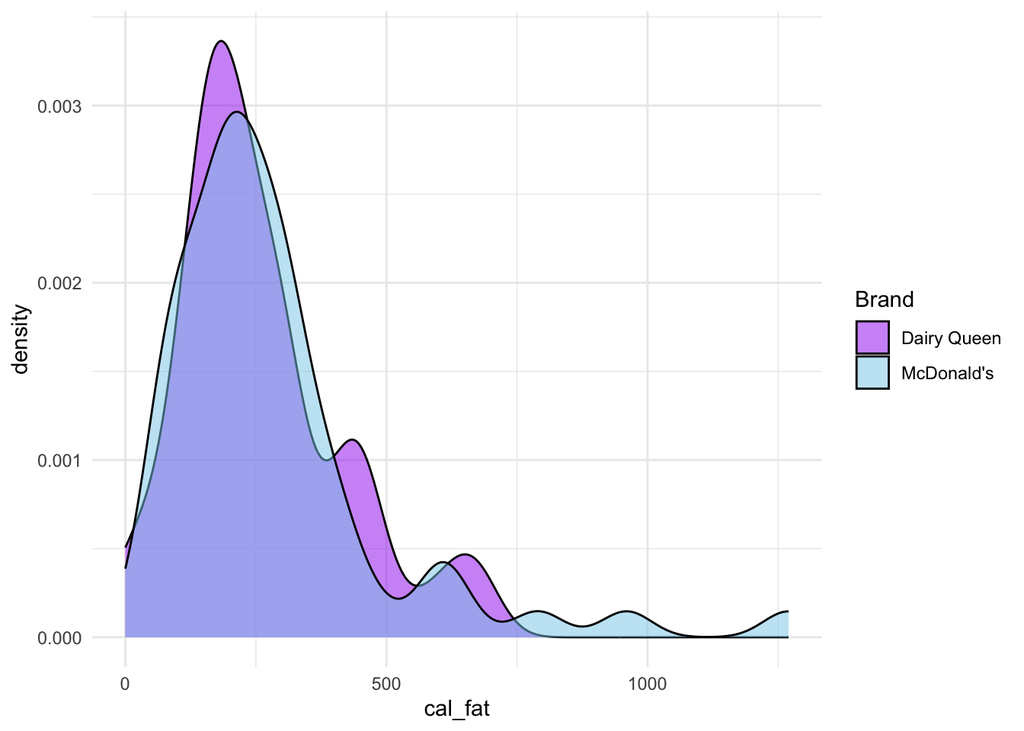

```r
ggplot(mcd_dq, aes(x = cal_fat, fill = restaurant)) +
  geom_density(alpha = 0.5) +
  scale_fill_manual(name = "Brand", values = c('McDonald\'s' = 'skyblue', 'Dairy Queen' = 'purple')) +
  theme_minimal()
```

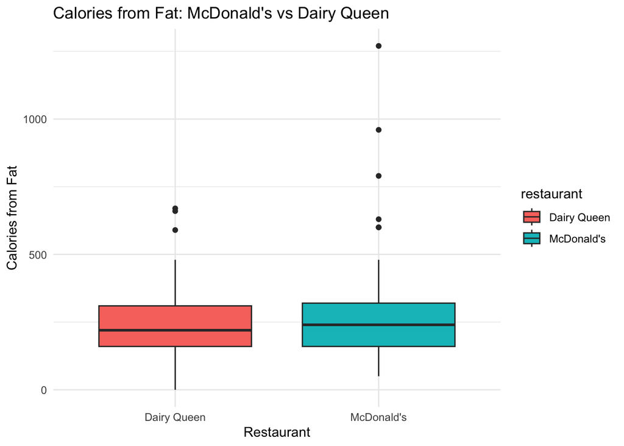

```r
ggplot(mcd_dq, aes(x = restaurant, y = cal_fat, fill = restaurant)) +
  geom_boxplot() +
  labs(title = "Calories from Fat: McDonald's vs Dairy Queen",
       x = "Restaurant",
       y = "Calories from Fat") +
  theme_minimal()
```

## The normal distribution

In your description of the distributions, did you use words like *bell-shaped*or *normal*? It’s tempting to say so when faced with a unimodal symmetric distribution.

Kevin Note: I didn’t and I prefer to use more descriptive terms since the chart was normal-ish. The “ish” warrants a dive.

To see how accurate that description is, you can plot a normal distribution curve on top of a histogram to see how closely the data follow a normal distribution. This normal curve should have the same mean and standard deviation as the data. You’ll be focusing on calories from fat from Dairy Queen products, so let’s store them as a separate object and then calculate some statistics that will be referenced later.

```r
dqmean <- mean(dairy_queen$cal_fat)
dqsd   <- sd(dairy_queen$cal_fat)
```

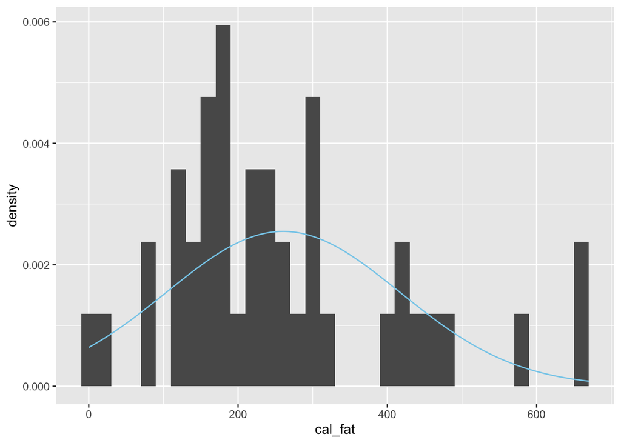

```r
ggplot(dairy_queen, aes(x = cal_fat)) +
  geom_blank() +
  geom_histogram(aes(y = ..density..), binwidth = 20) +
  stat_function(fun = dnorm, args = c(mean = dqmean, sd = dqsd), col = "skyblue")
```

After initializing a blank plot with `geom_blank()`, the `ggplot2` package (within the `tidyverse`) allows us to add additional layers. The first layer is a density histogram. The second layer is a statistical function – the density of the normal curve, `dnorm`. We specify that we want the curve to have the same mean and standard deviation as the column of fat calories. The argument `col` simply sets the color for the line to be drawn. If we left it out, the line would be drawn in black.

2. Based on the this plot, does it appear that the data follow a nearly normal distribution?

Yes, the data appears normal. While the black bars plotting the density have gaps between them, this a function of dataset size. With enough data, it would start to fill in a normal curve shape. The line drawn on the graph is a normal curve but the peak would be higher for the data than the line plotted.

## Evaluating the normal distribution

Eyeballing the shape of the histogram is one way to determine if the data appear to be nearly normally distributed, but it can be frustrating to decide just how close the histogram is to the curve. An alternative approach involves constructing a normal probability plot, also called a normal Q-Q plot for “quantile-quantile”.

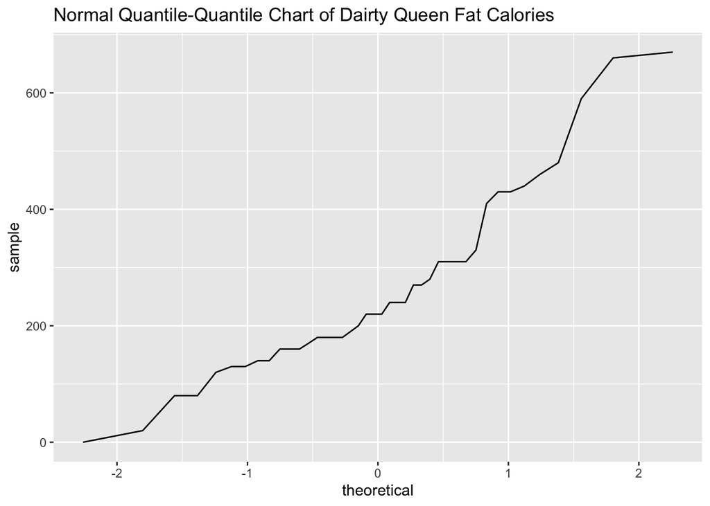

```r
ggplot(data = dairy_queen, aes(sample = cal_fat)) +
  geom_line(stat = "qq") +
  labs(title = "Normal Quantile-Quantile Chart of Dairty Queen Fat Calories")
```

This time, you can use the `geom_line()` layer, while specifying that you will be creating a Q-Q plot with the `stat` argument. It’s important to note that here, instead of using `x` instead `aes()`, you need to use `sample`.

The x-axis values correspond to the quantiles of a theoretically normal curve with mean 0 and standard deviation 1 (i.e., the standard normal distribution). The y-axis values correspond to the quantiles of the original unstandardized sample data. However, even if we were to standardize the sample data values, the Q-Q plot would look identical. A data set that is nearly normal will result in a probability plot where the points closely follow a diagonal line. Any deviations from normality leads to deviations of these points from that line.

The plot for Dairy Queen’s calories from fat shows points that tend to follow the line but with some errant points towards the upper tail. You’re left with the same problem that we encountered with the histogram above: how close is close enough?

A useful way to address this question is to rephrase it as: what do probability plots look like for data that I *know* came from a normal distribution? We can answer this by simulating data from a normal distribution using `rnorm`.

```r
sim_norm <- rnorm(n = nrow(dairy_queen), mean = dqmean, sd = dqsd)
```

The first argument indicates how many numbers you’d like to generate, which we specify to be the same number of menu items in the `dairy_queen` data set using the `nrow()` function. The last two arguments determine the mean and standard deviation of the normal distribution from which the simulated sample will be generated. You can take a look at the shape of our simulated data set, `sim_norm`, as well as its normal probability plot.

3. Make a normal probability plot of `sim_norm`. Do all of the points fall on the line? How does this plot compare to the probability plot for the real data? (Since `sim_norm` is not a data frame, it can be put directly into the `sample` argument and the `data` argument can be dropped.)